# Individual Project Report

Author

Matthew Kelsall

[figure not shown]

## Data Acquisition

As a team, we began by exploring a wide range of publicly available datasets, focusing on those that were both large and vast enough to support an interesting research question. After reviewing several options, we reconvened to share our findings and decided to move forward with datasets related to public health and restaurant inspections in New York City. These data sources were well-suited to our overarching goal of examining the relationship between restaurant quality and community health across NYC neighborhoods.

```r
library(readxl); library(tibble); library(dplyr)
library(tidyverse); library(ggplot2); library(reshape2)
library(lubridate); library(scales)
library(forcats); library(patchwork); library(scales);
library(DT); library(glue); library(httr2); library(sf)

community_health_df <- function() {
  # Source url and file names
  src_url  <- "https://www.nyc.gov/assets/doh/downloads/excel/episrv/2022-chp-pud.xlsx"
  src_name <- basename(src_url)

  # Destination paths
  dest_dir  <- file.path("data", "finproj")
  dest_file <- file.path(dest_dir, src_name)

  if (!dir.exists(dest_dir)) {
    dir.create(dest_dir, recursive = TRUE)
  }

  if (!file.exists(dest_file)) {
    message("Downloading: ", src_url)

    utils::download.file(src_url, dest_file, mode = "wb", quiet = TRUE)
    message("File saved to: ", dest_file)
  } else {
    message("File already exists in destination: ", dest_file)
  }


  df <- readxl::read_excel(dest_file, sheet = "CHP_all_data", skip = 1)


  df <- df[-c(66:69), ]

  return(df)
}

community_health<-community_health_df()


community_health <- community_health |>
  mutate(across(where(is.character), ~ na_if(., "n/a")))

is_borough_level <- community_health$ID %in% 0:5
#Bourough rows
ch_boroughs <- subset(community_health, is_borough_level)
#Community District rows
ch_neighbor <- subset(community_health, !is_borough_level)


inspection_df <- read.csv("C:/Users/mkels/OneDrive/Documents/STA9750-2025-FALL/DOHMH_New_York_City_Restaurant_Inspection_Results_20251103.csv")
```

One of the primary data sources used in this project is the DOHMH New York City Restaurant Inspection Results dataset. This dataset is described as containing every violation citation from each inspection conducted up to three years prior to a restaurant’s most recent inspection. It includes inspections for both restaurants and college cafeterias throughout the city.

Each row in the dataset represents a single restaurant violation citation and includes detailed information such as a unique restaurant identifier, restaurant name, borough, address, phone number, inspection date, assigned grade, and the associated violation description and code. The depth and granularity of this data source allowed for a comprehensive analysis of restaurant cleanliness and compliance with health regulations, making it a strong foundation for exploring patterns in restaurant quality across different neighborhoods.

Another key data source used in this project is the NYC Community Health Profile, which captures the health characteristics of 59 community districts across New York City. This data source provides a comprehensive overview of demographic, socioeconomic, and health-related indicators for each district, allowing for meaningful comparisons across neighborhoods.

The Community Health Profile includes a wide range of variables, such as population size, education levels, unemployment rates, rent burden, and other socioeconomic measures, as well as critical health outcomes including obesity rates, diabetes prevalence, and life expectancy. Together, these indicators offer valuable context for understanding the health and economic conditions within each community. By integrating this data source with restaurant inspection data, we are able to examine our overarching question, how neighborhood-level economic factors and health outcomes may relate to restaurant quality across New York City.

## Data Cleaning, Preparation, and Exploration

Data visualization tools such as Tableau were initially used to explore the data sources and develop a deeper understanding of their structure and available variables. Tableau’s drag-and-drop functionality made it possible to quickly visualize patterns, assess data quality, and identify which columns were most informative for the analysis. This exploratory step helped guide data cleaning and preparation.

Before analysis could proceed, the data sources required cleaning and integration. To successfully join the DOHMH Restaurant Inspection Results data with the NYC Community Health Profiles, a bridge between the two data sources was created. The Community Health Profiles data contained neighborhood-level identifiers, with values such as Central Harlem, Queens Village, and Coney Island, while the DOHMH inspection data identified restaurant locations by ZIP code.

To address this mismatch, a new field was created to group ZIP codes and map them to their corresponding neighborhoods, aligning restaurant records with the neighborhood definitions used in the Community Health Profiles data source. This step ensured that the data sources could be accurately joined and analyzed together. The code used to create this bridge is shown below.

```r
inspection_df <- inspection_df %>%
  mutate(
    neighborhood_group = case_when(
      ZIPCODE %in% c(10031, 10032, 10033, 10034, 10040) ~ "Washington Heights and Inwood",
      ZIPCODE %in% c(10026, 10030, 10037, 10039) ~ "Central Harlem",
      ZIPCODE %in% c(10029, 10035) ~ "East Harlem",
      ZIPCODE %in% c(10023, 10024) ~ "Upper West Side",
      ZIPCODE %in% c(10021, 10028, 10044, 10065, 10075, 10128) ~ "Upper East Side",
      ZIPCODE %in% c(10001, 10011, 10018, 10019, 10020, 10036) ~ "Clinton and Chelsea",
      ZIPCODE %in% c(10010, 10016, 10017, 10022) ~ "Stuyvesant Town and Turtle Bay",
      ZIPCODE %in% c(10012, 10013, 10014) ~ "Greenwich Village and Soho",
      ZIPCODE %in% c(10002, 10003, 10009) ~ "Lower East Side and Chinatown",
      ZIPCODE %in% c(10004, 10005, 10006, 10007, 10038, 10280) ~ "Financial District",
      ZIPCODE %in% c(10025, 10027) ~ "Morningside Heights and Hamilton Heights",

      ZIPCODE %in% c(10301, 10302, 10303, 10304, 10305, 10310) ~ "St. George and Stapleton",
      ZIPCODE %in% c(10306, 10314) ~ "South Beach and Willowbrook",
      ZIPCODE %in% c(10307, 10308, 10309, 10312) ~ "Tottenville and Great Kills",

      ZIPCODE %in% c(10451, 10454, 10455, 10456, 10459) ~ "Mott Haven and Melrose",
      ZIPCODE %in% c(10474, 10475) ~ "Hunts Point and Longwood",
      ZIPCODE %in% c(10453, 10457, 10458, 10460) ~ "Morrisania and Crotona",
      ZIPCODE %in% c(10452, 10456, 10451) ~ "Highbridge and Concourse",
      ZIPCODE %in% c(10453, 10458, 10467, 10468) ~ "Fordham and University Heights",
      ZIPCODE %in% c(10457, 10458, 10461) ~ "Belmont and East Tremont",
      ZIPCODE %in% c(10463, 10471) ~ "Kingsbridge Heights and Bedford",
      ZIPCODE %in% c(10463, 10471) ~ "Riverdale and Fieldston",
      ZIPCODE %in% c(10462, 10473) ~ "Parkchester and Soundview",
      ZIPCODE %in% c(10461, 10465, 10472, 10473) ~ "Throgs Neck and Co-op City",
      ZIPCODE %in% c(10461, 10462) ~ "Morris Park and Bronxdale",
      ZIPCODE %in% c(10466, 10467, 10469) ~ "Williamsbridge and Baychester",

      ZIPCODE %in% c(11211, 11222) ~ "Greenpoint and Williamsburg",
      ZIPCODE %in% c(11201, 11205) ~ "Fort Greene and Brooklyn Heights",
      ZIPCODE %in% c(11206, 11216, 11221, 11233, 11238) ~ "Bedford Stuyvesant",
      ZIPCODE %in% c(11207, 11221, 11237) ~ "Bushwick",
      ZIPCODE %in% c(11207, 11208) ~ "East New York and Starrett City",
      ZIPCODE %in% c(11215, 11217, 11231) ~ "Park Slope and Carroll Gardens",
      ZIPCODE %in% c(11220, 11232) ~ "Sunset Park",
      ZIPCODE %in% c(11213, 11216, 11225, 11238) ~ "Crown Heights and Prospect Heights",
      ZIPCODE %in% c(11203, 11212) ~ "South Crown Heights and Lefferts Gardens",
      ZIPCODE %in% c(11209, 11220) ~ "Bay Ridge and Dyker Heights",
      ZIPCODE %in% c(11204, 11214, 11228) ~ "Bensonhurst",
      ZIPCODE %in% c(11204, 11218, 11219, 11230) ~ "Borough Park",
      ZIPCODE %in% c(11224) ~ "Coney Island",
      ZIPCODE %in% c(11203, 11210, 11226) ~ "Flatbush and Midwood",
      ZIPCODE %in% c(11235) ~ "Sheepshead Bay",
      ZIPCODE %in% c(11212, 11233) ~ "Brownsville",
      ZIPCODE %in% c(11203, 11226, 11230) ~ "East Flatbush",
      ZIPCODE %in% c(11236, 11234) ~ "Flatlands and Canarsie",

      ZIPCODE %in% c(11101, 11102, 11103, 11104, 11105, 11106, 11369, 11370, 11377) ~ "Long Island City and Astoria",
      ZIPCODE %in% c(11377, 11378, 11379) ~ "Woodside and Sunnyside",
      ZIPCODE %in% c(11372, 11373, 11374) ~ "Jackson Heights",
      ZIPCODE %in% c(11373, 11375, 11368) ~ "Elmhurst and Corona",
      ZIPCODE %in% c(11385, 11378) ~ "Ridgewood and Maspeth",
      ZIPCODE %in% c(11374, 11375, 11385) ~ "Rego Park and Forest Hills",
      ZIPCODE %in% c(11354, 11355, 11356, 11357, 11358) ~ "Flushing and Whitestone",
      ZIPCODE %in% c(11365, 11366, 11367) ~ "Hillcrest and Fresh Meadows",
      ZIPCODE %in% c(11415, 11416, 11421) ~ "Kew Gardens and Woodhaven",
      ZIPCODE %in% c(11417, 11419, 11420) ~ "South Ozone Park and Howard Beach",
      ZIPCODE %in% c(11360, 11361, 11362) ~ "Bayside and Little Neck",
      ZIPCODE %in% c(11412, 11423, 11432, 11433, 11434) ~ "Jamaica and Hollis",
      ZIPCODE %in% c(11427, 11428, 11429) ~ "Queens Village",
      ZIPCODE %in% c(11691, 11692, 11693, 11694, 11695) ~ "Rockaway and Broad Channel",
      TRUE ~ NA_character_
    )
  )
```

To support spatial analysis and mapping, approximate geographic coordinates were added for each neighborhood. A reference table was created that assigns a representative latitude and longitude to the center of each community district, based on commonly accepted neighborhood boundaries. These coordinates allowed neighborhood-level health and inspection metrics to be plotted geographically, enabling visual comparisons across the city and supporting map-based visualizations in later stages of the analysis.

```r
# Neighborhood coordinates (approximate centers)
neighborhood_coords <- data.frame(
  Name = c(
    "Financial District",
    "Greenwich Village and Soho",
    "Lower East Side and Chinatown",
    "Clinton and Chelsea",
    "Midtown",
    "Stuyvesant Town and Turtle Bay",
    "Upper West Side",
    "Upper East Side",
    "Morningside Heights and Hamilton Heights",
    "Central Harlem",
    "East Harlem",
    "Washington Heights and Inwood",
    "Mott Haven and Melrose",
    "Hunts Point and Longwood",
    "Morrisania and Crotona",
    "Highbridge and Concourse",
    "Fordham and University Heights",
    "Belmont and East Tremont",
    "Kingsbridge Heights and Bedford",
    "Riverdale and Fieldston",
    "Parkchester and Soundview",
    "Throgs Neck and Co-op City",
    "Morris Park and Bronxdale",
    "Williamsbridge and Baychester",
    "Greenpoint and Williamsburg",
    "Fort Greene and Brooklyn Heights",
    "Bedford Stuyvesant",
    "Bushwick",
    "East New York and Starrett City",
    "Park Slope and Carroll Gardens",
    "Sunset Park",
    "Crown Heights and Prospect Heights",
    "South Crown Heights and Lefferts Gardens",
    "Bay Ridge and Dyker Heights",
    "Bensonhurst",
    "Borough Park",
    "Coney Island",
    "Flatbush and Midwood",
    "Sheepshead Bay",
    "Brownsville",
    "East Flatbush",
    "Flatlands and Canarsie",
    "Long Island City and Astoria",
    "Woodside and Sunnyside",
    "Jackson Heights",
    "Elmhurst and Corona",
    "Ridgewood and Maspeth",
    "Rego Park and Forest Hills",
    "Flushing and Whitestone",
    "Hillcrest and Fresh Meadows",
    "Kew Gardens and Woodhaven",
    "South Ozone Park and Howard Beach",
    "Bayside and Little Neck",
    "Jamaica and Hollis",
    "Queens Village",
    "Rockaway and Broad Channel",
    "St. George and Stapleton",
    "South Beach and Willowbrook",
    "Tottenville and Great Kills"
  ),
  lon = c(
    -74.010, -73.996, -73.989, -73.993, -73.981, -73.967, -73.976, -73.959, -73.957, -73.944,
    -73.940, -73.930, -73.912, -73.887, -73.898, -73.915, -73.906, -73.878, -73.891, -73.905,
    -73.856, -73.820, -73.843, -73.860, -73.952, -73.974, -73.944, -73.918, -73.980, -73.988,
    -73.971, -73.949, -73.985, -73.981, -73.965, -73.975, -73.978, -73.961, -73.943, -73.906,
    -73.912, -73.915, -73.925, -73.919, -73.885, -73.873, -73.908, -73.829, -73.800, -73.820,
    -73.750, -73.778, -73.740, -73.766, -74.071, -74.096, -74.086, -74.079, -74.081
  ),
  lat = c(
    40.707, 40.733, 40.715, 40.746, 40.754, 40.734, 40.787, 40.773, 40.809, 40.811,
    40.792, 40.844, 40.814, 40.818, 40.831, 40.841, 40.858, 40.852, 40.879, 40.902,
    40.840, 40.832, 40.836, 40.857, 40.724, 40.686, 40.683, 40.696, 40.676, 40.645,
    40.640, 40.647, 40.631, 40.634, 40.618, 40.609, 40.618, 40.620, 40.574, 40.655,
    40.612, 40.640, 40.617, 40.743, 40.744, 40.750, 40.737, 40.721, 40.746, 40.730,
    40.729, 40.601, 40.644, 40.718, 40.637, 40.525, 40.632, 40.621, 40.585
  )
)
```

```r
if (!file.exists("data/mp03/nycc_25c.shp")) {

  # Create directory if needed
  dir.create("data/mp03", showWarnings = FALSE, recursive = TRUE)

  # --- Load required packages ---
  if (!require("sf")) install.packages("sf")
  library(sf)

  if (!require("utils")) install.packages("utils")  # for download.file, unzip
  library(utils)

  # --- Define constants ---
  ZIP_URL  <- "https://s-media.nyc.gov/agencies/dcp/assets/files/zip/data-tools/bytes/city-council/nycc_25c.zip"
  ZIP_PATH <- "data/mp03/nycc_25c.zip"
  EXTRACT_DIR <- "data/mp03"

  # --- Step 1: Download if not already there ---
  if (!file.exists(ZIP_PATH)) {
    #cat("Downloading NYC Council District boundaries...\n")
    download.file(ZIP_URL, destfile = ZIP_PATH, mode = "wb")
    #cat("Download complete:", ZIP_PATH, "\n")
  } else {
    #cat("Zip file already exists. Skipping download.\n")
  }

  # --- Step 2: Unzip only if needed ---
  if (length(list.files(EXTRACT_DIR, pattern = "\\.shp$", full.names = TRUE, recursive = TRUE)) == 0) {
    #cat("Extracting zip file...\n")
    unzip(ZIP_PATH, exdir = EXTRACT_DIR)
    #cat("Extraction complete.\n")
  } else {
    #cat("Files already extracted. Skipping unzip.\n")
  }

  # --- Step 3: Read shapefile ---
  shp_file <- list.files(EXTRACT_DIR, pattern = "\\.shp$", full.names = TRUE, recursive = TRUE)[1]

  if (is.na(shp_file)) {
    stop("No shapefile found in extracted contents. Please verify the zip file.")
  }

  #cat("Reading shapefile:", shp_file, "\n")
  nycc_boundaries <- st_read(shp_file, quiet = TRUE)
  #cat("Read complete.\n")

  # --- Step 4: Transform CRS to WGS84 ---
  nycc_boundaries <- st_transform(nycc_boundaries, crs = "WGS84")
  #cat("Coordinate system transformed to WGS84.\n")

  # --- Step 5: Save the transformed shapefile for future use ---
  st_write(nycc_boundaries, "data/mp03/nycc_25c_wgs84.shp", delete_dsn = TRUE, quiet = TRUE)
  #cat("Saved transformed shapefile to data/mp03/nycc_25c_wgs84.shp\n")

} else {
  #cat("Shapefile already exists. Skipping download and transformation.\n")
}

# --- Step 6: Return the data object ---
nycc_boundaries <- st_read("data/mp03/nycc_25c_wgs84.shp", quiet = TRUE)
```

## Data Analysis & Visualization

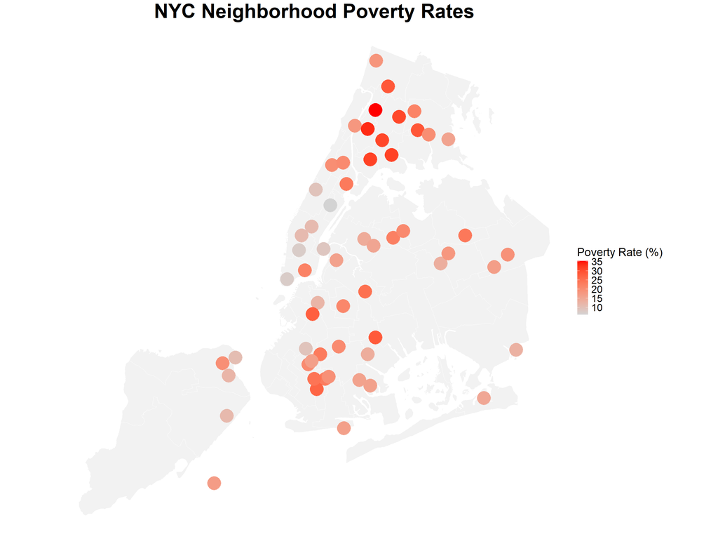

```r
poverty_df <- community_health_df() %>%
  select(Name, Poverty) %>%
  left_join(neighborhood_coords, by = "Name")

# Remove rows with missing coordinates
poverty_df_clean <- poverty_df %>%
  filter(!is.na(lon) & !is.na(lat))

# Convert to sf
poverty_sf <- st_as_sf(poverty_df_clean, coords = c("lon", "lat"), crs = 4326)

ggplot() +
  geom_sf(data = nycc_boundaries, fill = "grey95", color = "white") +
  geom_sf(data = poverty_sf, aes(color = Poverty), size = 10) +
  scale_color_gradient(low = "lightgrey", high = "red", name = "Poverty Rate (%)") +
  labs(title = "NYC Neighborhood Poverty Rates") +
  theme_void() +  # Removes axes, ticks, background
  theme(
    plot.title = element_text(size = 32, face = "bold", hjust = 0.5),
    plot.subtitle = element_text(size = 22, hjust = 0.5),
    legend.title = element_text(size = 18),
    legend.text = element_text(size = 16)
  )
```

```r
# To make the figure larger when saving
ggsave("NYC_Poverty_Map.png", width = 16, height = 12, dpi = 300)
```

This scatter plot visualizes the relationship between neighborhood-level poverty rates and the rate of critical restaurant violations across New York City. The x-axis represents the poverty rate (%) in each neighborhood, while the y-axis shows the critical violation rate, defined as the proportion of all restaurant violations that are deemed critical. Each dot corresponds to a different neighborhood, with the color gradient indicating the relative poverty level. A linear trend line is included to help assess potential correlations, and specific neighborhoods with notable interest, high poverty neighborhoods Fordham and University Heights & Highbridge and Concourse, are labeled for emphasis. Overall, the plot demonstrates that there is little to no correlation between poverty and critical violation rates, suggesting that neighborhoods with the highest poverty levels exhibit roughly similar rates of critical violations compared to more affluent areas. This insight highlights that critical restaurant health issues are not strongly associated with neighborhood poverty in NYC

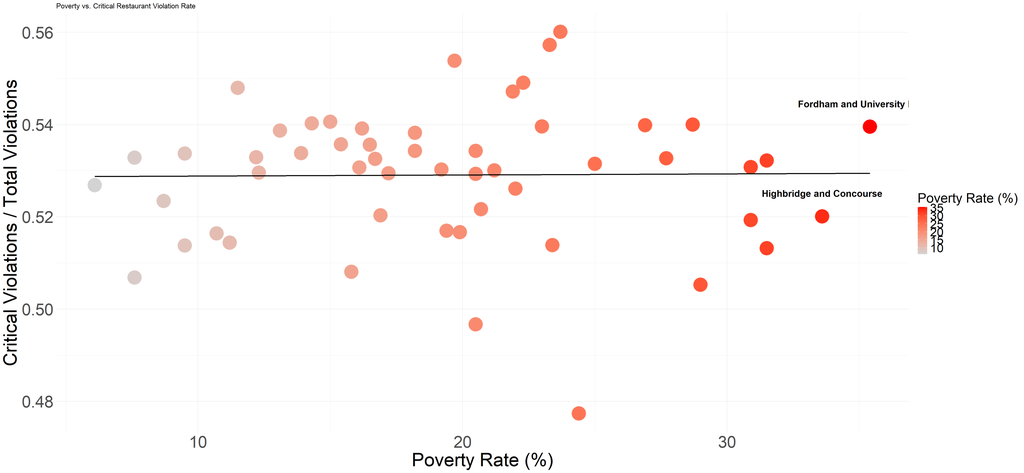

```r
community_health <- community_health_df()


critical_rates <- inspection_df %>%
  group_by(neighborhood_group) %>%
  summarize(
    total_violations = n(),
    critical_violations = sum(CRITICAL.FLAG == "Critical", na.rm = TRUE),
    critical_violation_rate = critical_violations / total_violations
  )

combined_df <- critical_rates %>%
  left_join(community_health,
            by = c("neighborhood_group" = "Name"))

ggplot(combined_df,
       aes(x = Poverty, y = critical_violation_rate, color = Poverty)) +
  geom_point(size = 12) +
  geom_smooth(method = "lm", se = FALSE, color = "black") +
  scale_color_gradient(low = "lightgrey", high = "red", name = "Poverty Rate (%)") +
  geom_text(
    data = combined_df %>%
      filter(neighborhood_group %in% c("Fordham and University Heights",
                                       "Highbridge and Concourse")),
    aes(label = neighborhood_group),
    color = "black",
    size = 6,
    fontface = "bold",
    nudge_y = 0.005   # adjust as needed
  ) +
  labs(
    title = "Poverty vs. Critical Restaurant Violation Rate",
    x = "Poverty Rate (%)",
    y = "Critical Violations / Total Violations"
  ) +
  theme_minimal() +
  theme(
    axis.text = element_text(size = 30),
    axis.title = element_text(size = 34),
    legend.title = element_text(size = 24),
    legend.text  = element_text(size = 22)
  )
```

## Overarching Question

#### *How does restaurant quality relate to community health across New York City neighborhoods?*

In the broader context of this project, which aims to understand how restaurant quality relates to community health across New York City neighborhoods, these findings suggest that restaurant inspections alone may not fully capture disparities in community health. Although higher poverty is often linked to poorer health outcomes, our analysis indicates that neighborhoods with higher poverty rates do not consistently experience more critical restaurant violations. This suggests that restaurant safety issues are distributed relatively evenly across the city, and that other neighborhood-level factors—such as access to healthcare, prevalence of chronic conditions, environmental conditions, and social determinants have a stronger impact on overall community health. While restaurant quality remains an important aspect of public health, it represents only one aspect of a larger picture of health equity across NYC neighborhoods. The analysis portrays the need to consider multiple many factors of community well-being when evaluating public health interventions and policies.

## Conclusion

This project examined the relationship between restaurant quality and community health across New York City neighborhoods by integrating restaurant inspection data with neighborhood-level health and socioeconomic indicators. Using DOHMH Restaurant Inspection Results alongside NYC Community Health Profiles, the analysis explored whether economic conditions were associated with higher rates of critical health violations in restaurants. Through careful data preparation, community mapping, and visualization, neighborhood-level patterns were evaluated both geographically and statistically.

The results indicate that neighborhoods with higher poverty rates do not consistently experience higher proportions of critical restaurant health violations. Instead, critical violations appear to be relatively evenly distributed across neighborhoods, regardless of socioeconomic status. This finding challenges common assumptions that poorer neighborhoods face worse restaurant safety outcomes and suggests that New York City’s inspection and enforcement processes may be applied relatively uniformly across communities. It also highlights that poverty alone is not a strong predictor of restaurant cleanliness or compliance with health regulations.

In the context of the broader research question, these findings suggest that restaurant quality does not fully explain observed differences in community health outcomes. While restaurant safety remains an important component of public health, broader neighborhood health is likely shaped by a wider set of factors, including access to healthcare, dietary patterns, environmental conditions, and the prevalence of chronic disease. Future research could build on this work by incorporating measures of food access, restaurant density, inspection frequency, and health outcomes such as obesity and diabetes to more fully understand how food environments interact with community health. This analysis underscores the complexity of health equity in New York City and the importance of considering multiple factors when designing policies to promote healthier communities.